# Lab 9

Author

Jacky Wu

# Setup

```r
library(tidyverse)
state_a <- read_csv(here::here("supporting_artifacts" , "Datasets" , "StateNames_A.csv")) %>%
  rename(Sex = Gender)
```

# Summarizing & Visualizing the Number of Allisons

## 1.

```r
state_allison <- state_a %>%
  filter(Name == 'Allison') %>%
  pivot_wider(names_from = Sex,
              values_from = Count) %>%
  mutate(M = replace_na(
    M, 0)
  ) %>%
  group_by(State) %>%
  summarize(across(
    'F':'M', .fns = sum)
  )
state_allison
```

```
# A tibble: 51 × 3
   State     F     M
   <chr> <dbl> <dbl>
 1 AK      232     0
 2 AL     1535     0
 3 AR     1198     0
 4 AZ     1880     0
 5 CA    12413     0
 6 CO     1594     0
 7 CT     1099     0
 8 DC      321     0
 9 DE      294     0
10 FL     4455     0
# … with 41 more rows
```

## 2.

```r
state_female <- state_a %>%
  filter(Sex == 'F')
```

## 3.

```r
allison_year <- state_female %>%
  filter(Name == 'Allison') %>%
  group_by(Year) %>%
  summarize(across(
    'Count', .fns = sum)
  )
allison_year
```

```
# A tibble: 18 × 2
    Year Count
   <dbl> <dbl>
 1  1997  7274
 2  1998  7861
 3  1999  7023
 4  2000  6314
 5  2001  6209
 6  2002  6237
 7  2003  5850
 8  2004  5871
 9  2005  5631
10  2006  5560
11  2007  5450
12  2008  6237
13  2009  6579
14  2010  5856
15  2011  5453
16  2012  5411
17  2013  5422
18  2014  5440
```

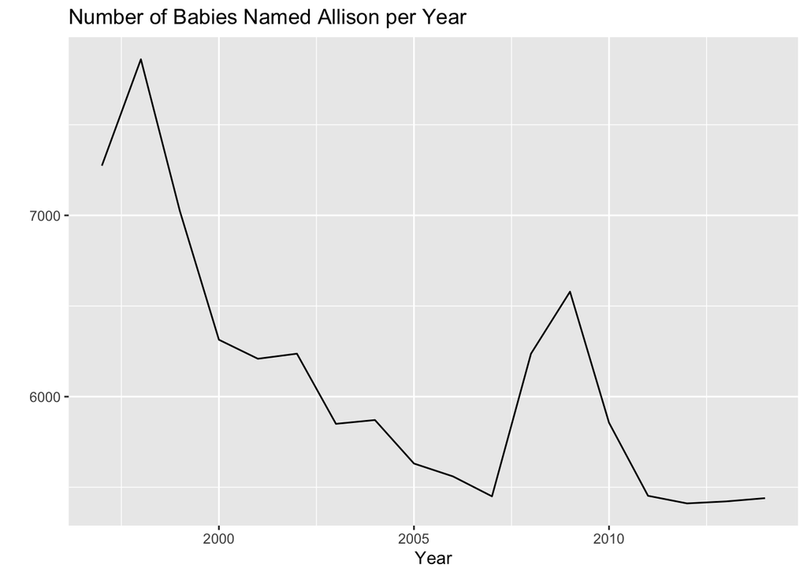

```r
ggplot(data = allison_year,
       mapping = aes(
         x = Year, y = Count)
       ) +
  geom_line() +
  labs(x = 'Year', y = '',
  title = 'Number of Babies Named Allison per Year')
```

# Modeling the Number of Allisons

## 4.

```r
allison_mod <- allison_year %>%
  lm(Count ~ Year, data = .)
```

## 5.

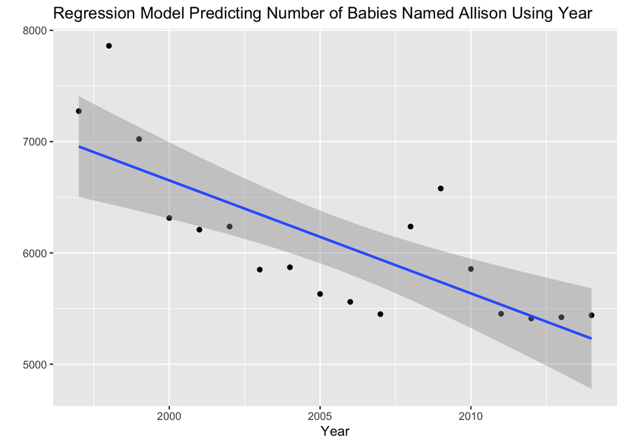

```r
ggplot(data = allison_year,
       mapping = aes(
         x = Year, y = Count)
       ) +
  geom_point() +
  stat_smooth(method = "lm") +
  labs(x = 'Year', y = '',
  title = 'Regression Model Predicting Number of Babies Named Allison Using Year')
```

## 6.

```r
summary(allison_mod)
```

```
Call:
lm(formula = Count ~ Year, data = .)

Residuals:
    Min      1Q  Median      3Q     Max
-512.98 -366.14  -52.11  257.33 1006.38

Coefficients:
             Estimate Std. Error t value Pr(>|t|)
(Intercept) 209689.76   42971.50   4.880 0.000167 ***
Year          -101.52      21.43  -4.738 0.000223 ***
---
Signif. codes:  0 '***' 0.001 '**' 0.01 '*' 0.05 '.' 0.1 ' ' 1

Residual standard error: 471.6 on 16 degrees of freedom
Multiple R-squared:  0.5839,    Adjusted R-squared:  0.5578
F-statistic: 22.45 on 1 and 16 DF,  p-value: 0.0002228
```

The estimate regression equation is:

Count = 209689.76 - 101.52(Year)

## 7.

```r
allison_df <- broom::augment(allison_mod)
```

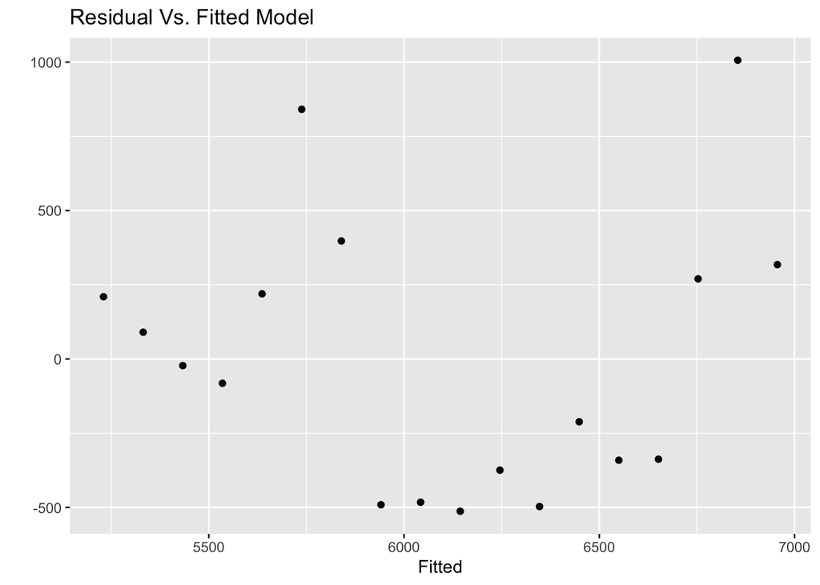

```r
ggplot(data = allison_df,
       mapping = aes(x = .fitted, y = .resid)
       ) +
  geom_point() +
  labs(x = 'Fitted', y = '',
  title = 'Residual Vs. Fitted Model')
```

Looking at the residual plot, there seems to be a curvature pattern which means that a linear model might not be the best fit for our model.

## 8.

It does seem like the name Allison isn’t as cool as it used to be. Our regression model shows that the predicted number of babies named Allison decreases by 101.52 as year increases by one. However, we need to be cautious with this conclusion since our residual plot shows a curvature pattern, which means that a linear model is not the best fit for our model.

# Spelling By State

## 9.

```r
state_allan <- state_a %>%
  filter(Sex == 'M',
         Name %in% c(
           'Allan', 'Alan', 'Allen')
         )
```

```r
allan_year <- state_allan %>%
  group_by(Name, Year) %>%
  summarize(across(
    'Count', .fns = sum)
  )
```

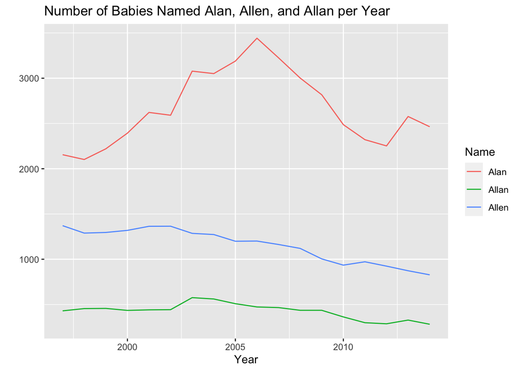

```r
ggplot(data = allan_year,
       mapping = aes(
         x = Year, y = Count, color = Name)
       ) +
  geom_line() +
  labs(x = 'Year', y = '',
  title = 'Number of Babies Named Alan, Allen, and Allan per Year')
```

## 10.

```r
allan_PA_CA <- state_allan %>%
  filter(Year == 2000,
         State %in% c(
           'PA','CA')
         ) %>%
  mutate(Count = replace_na(
    Count, 0)
    ) %>%
  pivot_wider(names_from = Name,
              values_from = Count)
allan_PA_CA
```

```
# A tibble: 2 × 6
   Year Sex   State  Alan Allen Allan
  <dbl> <chr> <chr> <dbl> <dbl> <dbl>
1  2000 M     CA      579   176   131
2  2000 M     PA       51    56    12
```

## 11.

```r
allan_percent <- allan_PA_CA %>%
  mutate(Total = rowSums(across(
    'Alan':'Allan')
    ),
    Alan = Alan/Total*100,
    Allen = Allen/Total*100,
    Allan = Allan/Total*100,
  ) %>%
  select(-Total)
allan_percent
```

```
# A tibble: 2 × 6
   Year Sex   State  Alan Allen Allan
  <dbl> <chr> <chr> <dbl> <dbl> <dbl>
1  2000 M     CA     65.3  19.9  14.8
2  2000 M     PA     42.9  47.1  10.1
```

I wanted to create a total column by adding the rows and this source helped me with this:

https://stackoverflow.com/questions/3991905/sum-rows-in-data-frame-or-matrix

For CA, the percent breakdowns for the three names are 65.35% for Alan, 19.85% for Allen, and 14.79% for Allan.

For PA, the percent breakdowns for the three names are 42.86% for Alan, 47.05% for Allen, and 10.08% for Allan.

This shows that Allan’s spelling of his name is unusual even in his home state of PA, having only 10% of people with this spelling out of the three names.